# Reproducible research…project1

Richard

May 10, 2020

## 1. Introduction

This project makes use of data from a personal activity monitoring device. This device collects data at 5 minute intervals through out the day. The data consists of two months of data from an anonymous individual collected during the months of October and November, 2012 and include the number of steps taken in 5 minute intervals each day.

The variables included in this dataset are:

1. steps: Number of steps taking in a 5-minute interval (missing values are coded as NA)
2. date: The date on which the measurement was taken in YYYY-MM-DD format interval: Identifier for the 5-minute interval in which measurement was taken

## 2. Getting and cleaning the data for analysis

```r
library(dplyr)
```

```r
library(ggplot2)
if(!file.exists("./data")){dir.create("./data")}

#These are the data for the project:
fileUrl <- "https://d396qusza40orc.cloudfront.net/repdata%2Fdata%2Factivity.zip"
download.file(fileUrl,destfile="./data/dataset1.zip")

# Unzip dataSet to my directory called data
unzip(zipfile="./data/dataset1.zip",exdir="./data")

steps_data1<-read.csv("./data/activity.csv")

#loading the data set into a table to make manupulation easy
steps_data<-tbl_df(steps_data1)
rm(steps_data1)

##Looking at the data
head(steps_data)
```

```
## # A tibble: 6 x 3
##   steps date       interval
##   <int> <fct>         <int>
## 1    NA 2012-10-01        0
## 2    NA 2012-10-01        5
## 3    NA 2012-10-01       10
## 4    NA 2012-10-01       15
## 5    NA 2012-10-01       20
## 6    NA 2012-10-01       25
```

```r
#How does the data look like
str(steps_data)
```

```
## tibble [17,568 x 3] (S3: tbl_df/tbl/data.frame)
##  $ steps   : int [1:17568] NA NA NA NA NA NA NA NA NA NA ...
##  $ date    : Factor w/ 61 levels "2012-10-01","2012-10-02",..: 1 1 1 1 1 1 1 1 1 1 ...
##  $ interval: int [1:17568] 0 5 10 15 20 25 30 35 40 45 ...
```

```r
#dimension
dim(steps_data)
```

```
## [1] 17568     3
```

```r
##
```

## 3. filtering the data to remove all the Na values in the steps variable

```r
f_steps_data<-filter(steps_data, !is.na(steps))

#properly formatting the data variable
f_steps_data$date<-as.Date(f_steps_data$date)

#summing all the date variable that corresponds to the same day steps were taken
sum_steps<-aggregate(f_steps_data$steps,by=list(f_steps_data$date),FUN=sum)
```

**This prints a histogram for the daily steps with NA’s.**

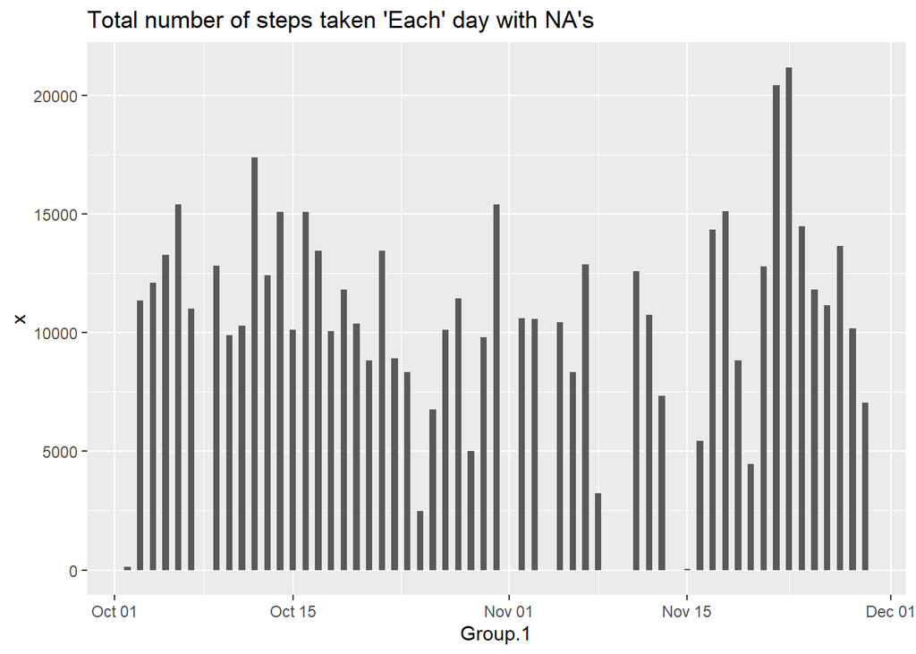

```r
data <-ggplot(sum_steps) +
  geom_bar(mapping = aes(x = Group.1, y =x ), stat = "identity", width=.5)+
  labs(title = "Total number of steps taken 'Each' day with NA's")
data
```

**sorting the higest steps day**

```r
top_steps_sorted<-arrange(sum_steps, desc(x))

# The highest number of steps is 21194 and occured on November 23rd 2012.
```

```r
###mean of steps each day
mean(top_steps_sorted$x)
```

```
## [1] 10766.19
```

```r
#10766.19

#median
median(top_steps_sorted$x)
```

```
## [1] 10765
```

```r
#10765
```

## 4. Making a time series plot of the of the 5-minute interval (x-axis)

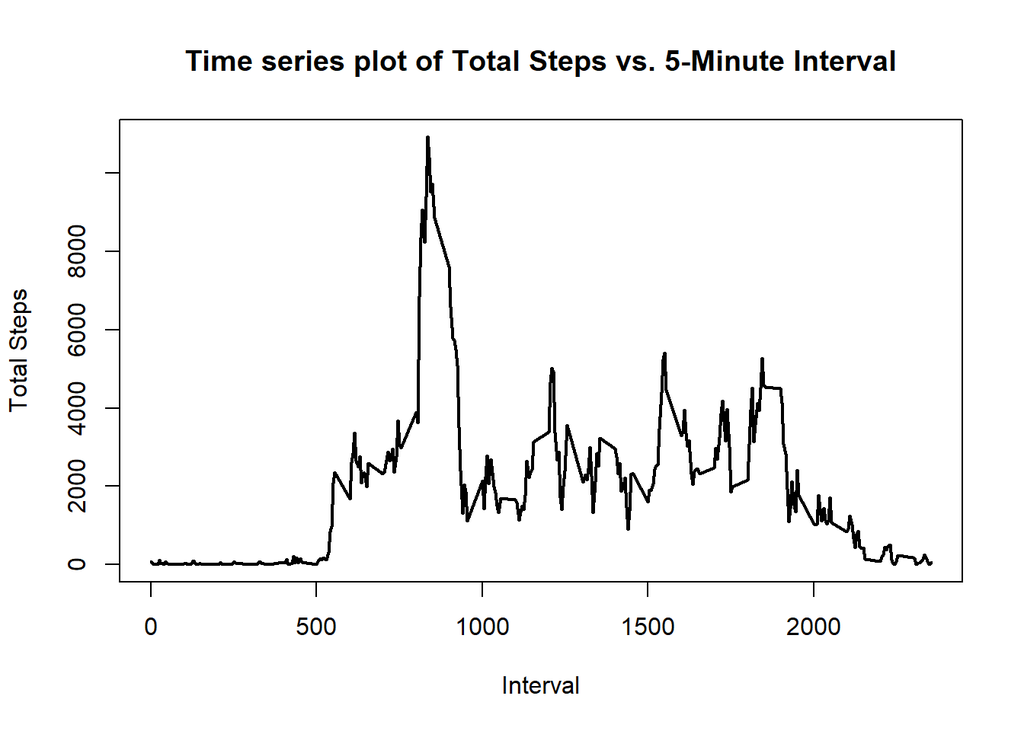

```r
suminterval <- aggregate(steps ~ interval, f_steps_data, FUN=sum)

plot(suminterval$interval, suminterval$steps,
     type = "l", lwd = 2,
     xlab = "Interval",
     ylab = "Total Steps",
     main = "Time series plot of Total Steps vs. 5-Minute Interval")
```

```r
##The 5-minute interval that, on average, contains the maximum number of steps
filter(suminterval, steps==max(steps))
```

```
##   interval steps
## 1      835 10927
```

```r
#10927 steps with the max number of steps and occured in the 835th interval

# Missiing data imputation
table(!is.na(steps_data))
```

```
##
## FALSE  TRUE
##  2304 50400
```

```r
#2304 missing data
```

**Strategy for filling all the missing data of NA’s**

```r
steps_data$steps[is.na(steps_data$steps)]<-mean(steps_data$steps,na.rm=TRUE)

head(steps_data)
```

```
## # A tibble: 6 x 3
##   steps date       interval
##   <dbl> <fct>         <int>
## 1  37.4 2012-10-01        0
## 2  37.4 2012-10-01        5
## 3  37.4 2012-10-01       10
## 4  37.4 2012-10-01       15
## 5  37.4 2012-10-01       20
## 6  37.4 2012-10-01       25
```

```r
sum_steps1<-aggregate(steps_data$steps,by=list(steps_data$date),FUN=sum)
```

** Histogram with the new dataset with the NA values filled with the mean**

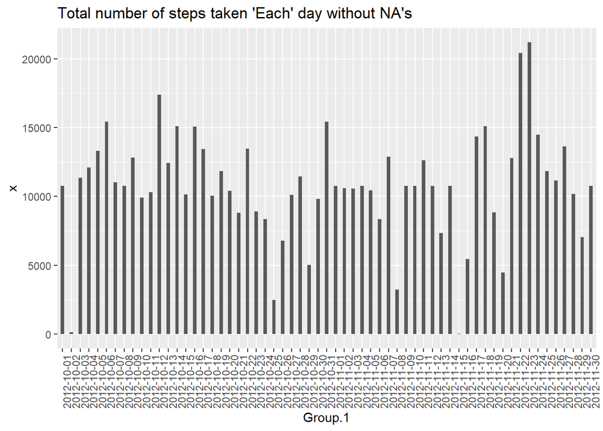

```r
#

data <-ggplot(sum_steps1) +
  geom_bar(mapping = aes(x = Group.1, y =x ), stat = "identity", width=0.4)+
  labs(title = "Total number of steps taken 'Each' day without NA's") +
  theme(axis.text.x = element_text(angle = 90))
data
```

```r
#####Mean of the steps taken when NA's are replaced
mean(sum_steps1$x)
```

```
## [1] 10766.19
```

```r
#####Median of the steps taken when NA's are replaced
median(sum_steps1$x)
```

```
## [1] 10766.19
```

**differences in activity patterns between weekdays and weekends**

```r
#Below code will use "chron" package, please install if not alrady installed
library(chron)
#is.weekend() function considers Saturday and Sunday as weekends
#In the output of below query FALSE means weekday, TRUE means weekend
table(is.weekend(steps_data$date))
```

```
##
## FALSE  TRUE
## 12960  4608
```

```r
#4608 weekends and 12960 weekdays

#Adding new factor variable "day_week" indicating whether a given date is a weekday or weekend day
steps_data$day_week <- ifelse(is.weekend(steps_data$date), "weekend", "weekday")

#Number of Weekdays and Weekends
table(steps_data$day_week)
```

```
##
## weekday weekend
##   12960    4608
```

**#Make a panel plot containing a time series plot (i.e. type = “l”) of the** **5-minute interval (x-axis)** **and the average number of steps taken, averaged across all weekday days or** **weekend days (y-axis).**

```r
mean_interval<- aggregate(steps ~ interval + day_week, steps_data, FUN=mean)

#Aggregated Data
head(mean_interval)
```

```
##   interval day_week    steps
## 1        0  weekday 7.006569
## 2        5  weekday 5.384347
## 3       10  weekday 5.139902
## 4       15  weekday 5.162124
## 5       20  weekday 5.073235
## 6       25  weekday 6.295458
```

**Making the panel plot**

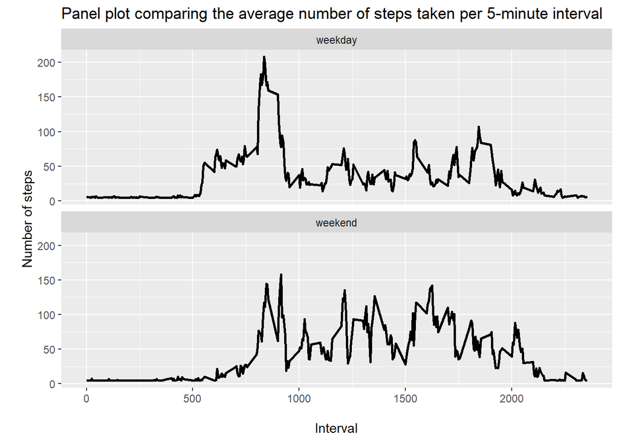

```r
ggplot(mean_interval, aes(x=interval, y=steps)) +
  geom_line(color="black", size=1) +
  facet_wrap(~day_week, nrow=2) +
  labs(x="\nInterval", y="\nNumber of steps")+
  labs(title = "Panel plot comparing the average number of steps taken per 5-minute interval ")
```